# Difference between Anomaly and Outliers

Kenan Sooklall

## Outlier

A legitimate data point that is far away from the mean or median in a distribution.

## Anomaly

An illegitimate data point that’s generated by a different process than whatever generated the rest of the data.

```
##        item cost
## 1     bagle 2.50
## 2    coffee 1.50
## 3     apple 0.65
## 4     water 2.50
## 5  sandwich 5.50
## 6     bagle 2.50
## 7    coffee 1.50
## 8     apple 0.65
## 9     water 2.50
## 10 sandwich 5.50
## 11    bagle 2.50
## 12   coffee 1.50
## 13    apple 0.65
## 14    water 2.50
```

[output cut: 16 more lines]

### The Outlier

Outliers are easy to detect because they can be explicitly defined.

- All values outside 3$\sigma$
- Values outside $1.5 \pm IQR$

Here we first try values outside 1 std, first scale the data then plot the histogram

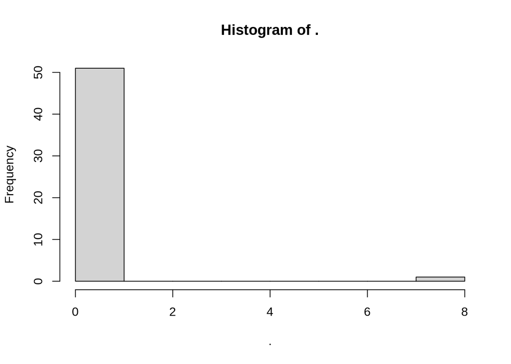

Imagine if this was a normal distribution that was right skewed the outlier is very obvious. Filter for values greater than 1.

```
##    item   cost  scale
## 1 4k_tv 799.99 7.0716
```

### The Anomaly

But how would you find the Anomaly or even if it exists

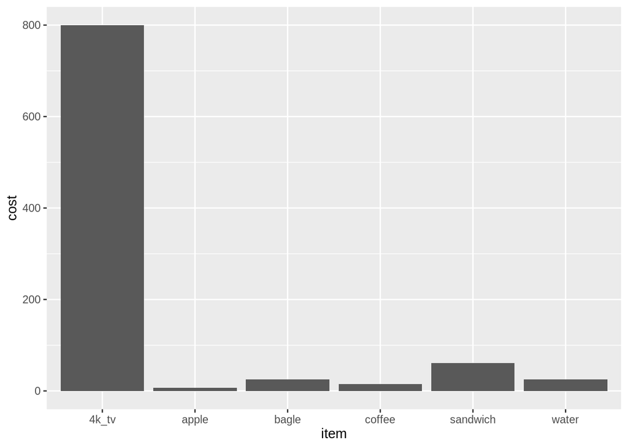

Everything looks normal and everything else is accounted for.

Try plotting it color change based on prices

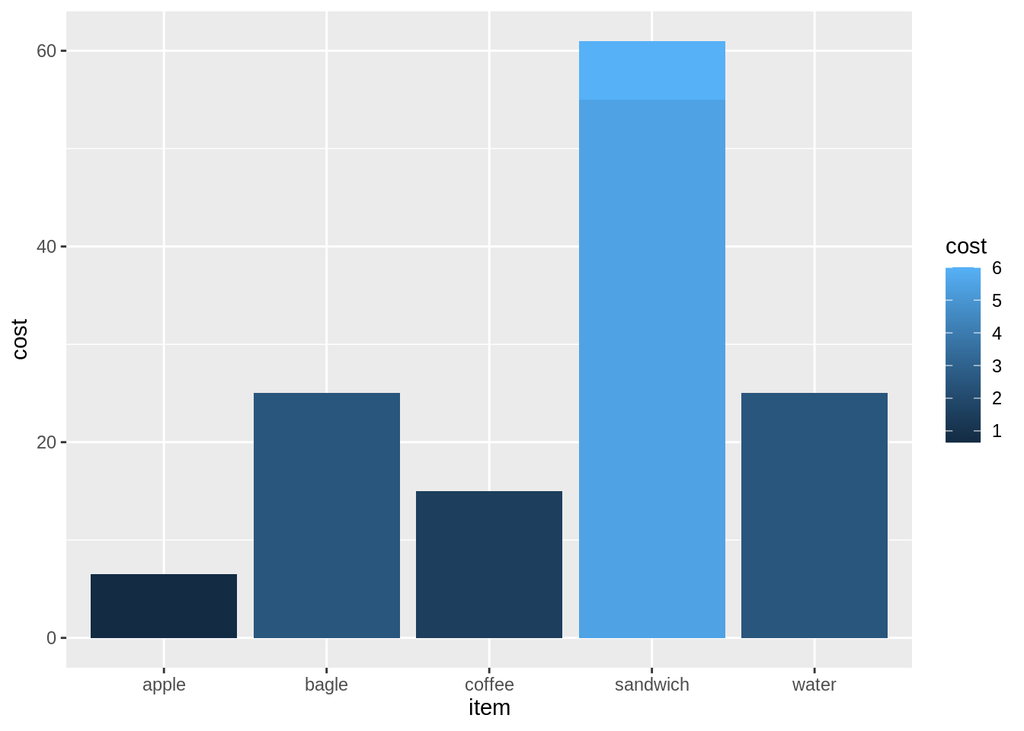

The light blue at the top of the sandwich bar stand out, filter the data on item==sandwich

```
##        item cost     scale
## 1  sandwich  5.5 0.1124184
## 2  sandwich  5.5 0.1124184
## 3  sandwich  5.5 0.1124184
## 4  sandwich  5.5 0.1124184
## 5  sandwich  5.5 0.1124184
## 6  sandwich  5.5 0.1124184
## 7  sandwich  5.5 0.1124184
## 8  sandwich  5.5 0.1124184
## 9  sandwich  5.5 0.1124184
## 10 sandwich  5.5 0.1124184
## 11 sandwich  6.0 0.1078973
```

Make a request to the accounting department to get location data and replot

```
##        item   cost     scale location
## 1     bagle   2.50 0.1395453       US
## 2    coffee   1.50 0.1485876       US
## 3     apple   0.65 0.1562736       US
## 4     water   2.50 0.1395453       US
## 5  sandwich   5.50 0.1124184       US
## 6     bagle   2.50 0.1395453       US
## 7    coffee   1.50 0.1485876       US
## 8     apple   0.65 0.1562736       US
## 9     water   2.50 0.1395453       US
## 10 sandwich   5.50 0.1124184       US
## 11    bagle   2.50 0.1395453       US
## 12   coffee   1.50 0.1485876       US
## 13    apple   0.65 0.1562736       US
## 14    water   2.50 0.1395453       US
```

[output cut: 38 more lines]

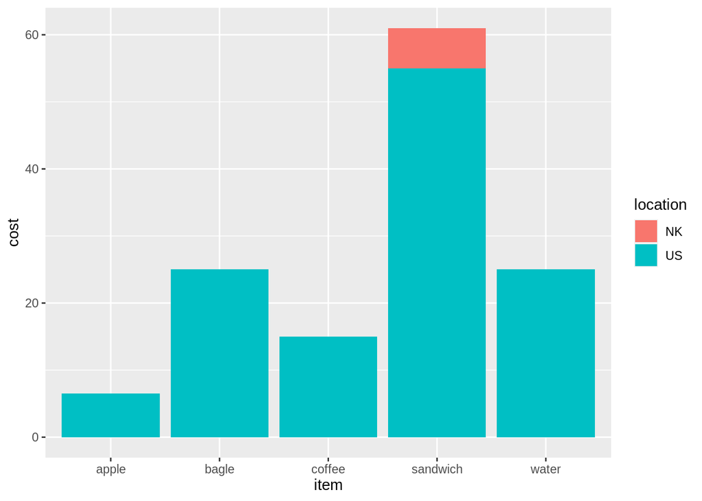

BAM!!! The anomaly found, the $6 cost wasn’t done by the customer

### Read world problems and cases

[Fradulent_cases](https://www.fincen.gov/resources/law-enforcement/case-examples?field_tags_investigation_target_id=678) that went to trial